# Problem Set 2 Key

#### Exercise 1

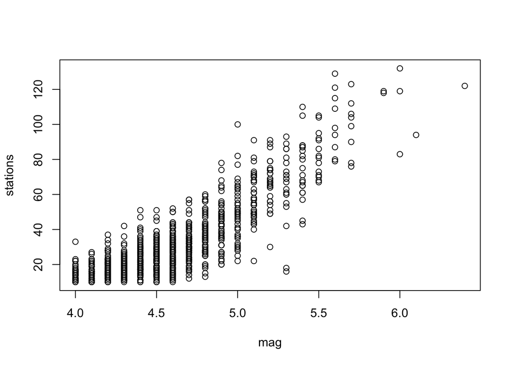

```r
data(quakes)
plot(stations ~ mag, data=quakes)
```

#### Exercise 2

If there were no relationship I would expect the slope to be 0, and the intercept to be the mean value of stations.

#### Exercise 3

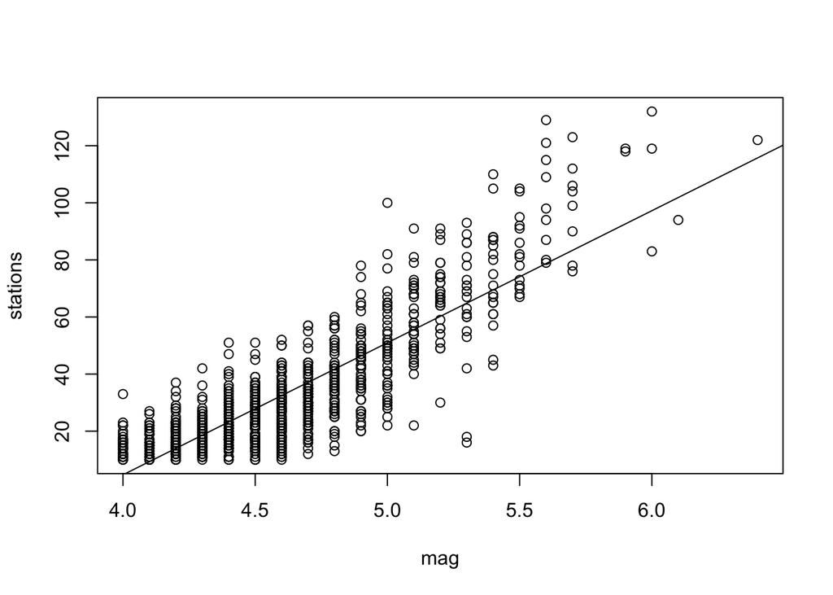

```r
m1 <- lm(stations~mag, data=quakes)
plot(stations ~ mag, data=quakes)
abline(m1)
```

```r
summary(m1)
```

```
##
## Call:
## lm(formula = stations ~ mag, data = quakes)
##
## Residuals:
##     Min      1Q  Median      3Q     Max
## -48.871  -7.102  -0.474   6.783  50.244
##
## Coefficients:
##              Estimate Std. Error t value Pr(>|t|)
## (Intercept) -180.4243     4.1899  -43.06   <2e-16 ***
## mag           46.2822     0.9034   51.23   <2e-16 ***
## ---
## Signif. codes:  0 '***' 0.001 '**' 0.01 '*' 0.05 '.' 0.1 ' ' 1
##
## Residual standard error: 11.5 on 998 degrees of freedom
## Multiple R-squared:  0.7245, Adjusted R-squared:  0.7242
## F-statistic:  2625 on 1 and 998 DF,  p-value: < 2.2e-16
```

```r
 m1$coefficients[1] + 4 * m1$coefficients[2]
```

```
## (Intercept)
##    4.704516
```

Considering our intercept had a std. error of 4.18, a calculated 4-intercept of 4.7 isn’t too far from 0. So, even though our data has a number of detections at mag 4, overall the trend suggests no detections there.

#### Exercise 4

To manually calculate the slope, I use the formula from the book:

```r
s <- quakes$stations
sb <- mean(s)
m <- quakes$mag
mb <- mean(m)
b1 <- sum((s - sb)*(m - mb))/ sum((m - mb)^2)
b1
```

```
## [1] 46.28221
```

This is the exact same value as given by `lm()`, so it checks out.

#### Exercise 5

Using Eq. 3.9 from the book, our interval is given by

$$\hat \beta_1 \pm 2 \cdot SE(\hat \beta_1),$$

where our standard error is given by

$$SE(\hat \beta_1) = \dfrac{\sigma} {\sqrt{\sum (x_i - \bar x)^2}}$$

but summary() gives the standard error of our slope to be 0.903, so let’s not calculate it over again.

```r
SEb1 <- summary(m1)$coefficients[2,2]
b1_upper <- b1 + 2 * SEb1
b1_lower <- b1 - 2 * SEb1
b1_upper
```

```
## [1] 48.089
```

```r
b1_lower
```

```
## [1] 44.47542
```

```r
confint(m1)
```

```
##                  2.5 %     97.5 %
## (Intercept) -188.64628 -172.20238
## mag           44.50944   48.05498
```

So our results are close, but strangely enough not exactly the same.

#### Exercise 6

Plugging in mag=7 to our model:

```r
 m1$coefficients[1] + 7 * m1$coefficients[2]
```

```
## (Intercept)
##    143.5511
```

So we would expect about 143 detections for a magnitude 7 earthquake

#### Exercise 7

1. We described the data by characterizing the relationship
2. This was a question about how a description of a model would change based on data
3. This was concerned with inferring trends in data based on the fitted model
4. Since we’re checking problem 3’s calculations, I guess this is also inference
5. The confidence interval helps to describe the data
6. This is an attempt at prediction

#### Exercise 9

```r
x <- quakes$mag
```

For this section, I simply reused the magnitude data from the actual dataset.

#### Exercise 10

```r
f_hat <- function(x)
{ m1$coefficients[1] + x * m1$coefficients[2]}
```

#### Exercise 11

```r
rss <- sum(m1$residuals^2)
sigma2 <- rss/(length(m1$residuals) - 2)
y <- f_hat(x) + rnorm(length(x), sd = sqrt(sigma2))
```

#### Exercise 12

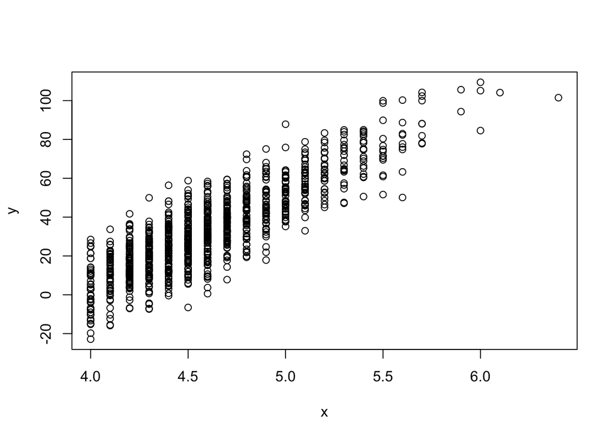

```r
plot(x,y)
```